# PTM First Pass

Erik VonKaenel

2024-07-16

Packages

```r
library(OrgMassSpecR)
library(tidyverse)
library(pmartR)

here::i_am("Code/ptm_example.Rmd")

seed = 1
```

Helper Functions

```r
add_char_at_n = function(original_string, new_char, n) {
  # Split the string into two parts
  part1 = substr(original_string, 1, n - 1)
  part2 = substr(original_string, n, nchar(original_string))

  # Concatenate the parts with the new character
  modified_string = paste0(part1, new_char, part2)

  return(modified_string)
}

generate_random_protein = function(n) {
  amino_acids = c("A", "R", "N", "D", "C", "E", "Q", "G", "H", "I",
                   "L", "K", "M", "F", "P", "S", "T", "W", "Y", "V")
  random_sequence = sample(amino_acids, size = n, replace = TRUE)
  random_sequence_string = paste(random_sequence, collapse = "")
  return(random_sequence_string)
}

add_ptms = function(sequence, amino_acid, identifier) {
  modified_string = str_replace_all(sequence, amino_acid, paste0(amino_acid, identifier))
  return(modified_string)
}

get_ptm_locations = function(sequence, amino_acid){
  return(stringr::str_locate_all(sequence, amino_acid)[[1]][,1])
}

get_ptm_site_mapping = function(sequence, amino_acid, drop_na = TRUE){
  digest_results = Digest(sequence)
  ptm_locations = get_ptm_locations(sequence, amino_acid)
  tmp_df = c()
  for(i in seq_along(ptm_locations)){
    peptide_id = which(ptm_locations[i] >= digest_results$start & ptm_locations[i] <= digest_results$stop)
    tmp_df = rbind(tmp_df, c(peptide = digest_results$peptide[peptide_id], site = paste0("@", amino_acid, ptm_locations[i])))
  }
  out = digest_results %>% left_join(., as_tibble(tmp_df), by = 'peptide') %>% mutate(protein = sequence)  %>% select(site, peptide, protein, start, stop)
  if(drop_na) out = out %>% filter(!is.na(site))
  return(out)
}

get_modify_indices = function(e_meta, sequence_abundance){
  unique_sites = unique(e_meta$site)
  num_sites = length(unique_sites)
  ptm_abundances = sample(seq_len(sequence_abundance), num_sites)
  modify_indices = sapply(ptm_abundances, \(x) seq_len(sequence_abundance) %in% sample(seq_len(sequence_abundance), x))
  colnames(modify_indices) = unique_sites
  return(modify_indices)
}

ptm_at_site = function(peptide, site, identifier, start){
  location = as.numeric(substr(site, 3, nchar(site))) - start + 2
  return(add_char_at_n(peptide, identifier, location))
}

ptm_at_sites = function(peptide, sites, identifier, start){
  for(site in sites){
    peptide = ptm_at_site(peptide, site, identifier = identifier, start = start)
    start = start - 1
  }
  return(peptide)
}

modify_and_count = function(e_meta, modify_indices){
  peps = unique(e_meta$peptide)
  out_dat = c()
  for(i in seq_along(peps)){
    pep_e_meta = e_meta %>% filter(peptide == peps[i])
    tmp_site = pep_e_meta %>% pull(site)
    site_modifications = matrix(modify_indices[,colnames(modify_indices) %in% tmp_site], ncol = length(tmp_site))
    colnames(site_modifications) = tmp_site
    site_modification_counts = table(apply(site_modifications, 1, \(x) paste0(colnames(site_modifications)[x], collapse = ";")))
    #drop no modification case here
    site_modification_counts = site_modification_counts[names(site_modification_counts) != '']

    for(j in seq_along(site_modification_counts)){
      curr_ptm = site_modification_counts[j]
      sites = strsplit(names(curr_ptm), split = ';')[[1]]
      ptm = ptm_at_sites(peps[i], sites, "#", pep_e_meta %>% filter(site %in% sites) %>% pull(start) %>% unique)
      out_dat = rbind(out_dat, tibble(peptide = ptm, site = sites, peptide_count = curr_ptm))
    }
  }
  return(out_dat)
}

generate_ptm_samples_for_sequence = function(ptm_site_mapping,
                                             sequence_abundances,
                                             subject_coefs,
                                             site_coefs,
                                             group_ids){
  #assert length(sequence_abundances) = length(subject_coef)

  e_data_full = c()
  e_meta_full = c()
  ground_truth = c()
  for(j in seq_along(sequence_abundances)){
    modify_indices = get_modify_indices(ptm_site_mapping, sequence_abundances[j]) #sequence should depend on group
    ground_truth = cbind(ground_truth, colSums(modify_indices))

    for(i in seq_len(sum(group_ids == 1))){
      e_data = modify_and_count(ptm_site_mapping, modify_indices)
      e_meta = e_data %>% rename(true_peptide_count = peptide_count)

      e_data_subj = e_data %>% mutate(peptide_count = peptide_count * exp(subject_coefs[i]))
      names(e_data_subj)[3] = paste0("Subject_", i, "_G", j)

      if(i == 1 & j == 1){
        e_data_full = e_data_subj
      } else {
        e_data_full = e_data_full %>%
          full_join(e_data_subj, by = c("peptide", "site")) %>%
          mutate_if(is.numeric,coalesce, 0)
      }

      if(i == 1) e_meta_full = rbind(e_meta_full, e_meta %>% mutate(group = j))
    }
  }

  coef_dat = tibble(Mult_Factor = exp(site_coefs), site = unique(e_meta_full$site))
  e_data_full = e_data_full %>%
    left_join(., coef_dat) %>%
    select(-site) %>%
    group_by(peptide) %>%
    summarise(Mult_Factor = prod(Mult_Factor),
              across(starts_with("Subject"), ~ mean(.x))) %>%
    mutate(across(starts_with("Subject"), ~ . * Mult_Factor)) %>%
    select(-Mult_Factor)

  return(list(e_data = e_data_full, e_meta = e_meta_full, ground_truth = ground_truth))
}
```

## PTM Rollup First Pass

Start by using a random sequence

```r
sequence = generate_random_protein(300)
print(sequence)
```

```
## [1] "HSHEMISMIQDFWTRNMHPAKWMISRFYDWTRFVQLRMAMWASWRVQHDGSTHNSVRHCK…"
```

We will target a modification on serine (S). Trypsin digestion is simulated without error.

```r
# set.seed(25)
amino_acid = "S"
identifier = "@"
```

Simulation setup:  
- 2 groups  
- 10 subjects per group  
- 1000 replicates of the sequence are simulated per subject  
- No subject effect  
- No site effect

Set simulation values:

```r
sequence_abundances = c(1000, 1000)

ptm_site_mapping = get_ptm_site_mapping(sequence, amino_acid)
# site_sd = 0.1
site_coefs = rep(0, length(unique(ptm_site_mapping$site)))

n_per_group = 10
# subject_effect_sd = 0.1
# subject_coefs = rnorm(n_per_group * 2, sd = subject_effect_sd)
subject_coefs = rep(0, n_per_group * 2)
```

PTM Sampling Scheme:  
For each PTM site, a random number of the 1000 unmodified proteins are selected to be modified at that site. This can be visualized for the first 20 proteins as below:

```r
tmp_dat = get_modify_indices(ptm_site_mapping, sequence_abundances[1])
rownames(tmp_dat) = paste0("Protein_", seq_len(1000))
head(tmp_dat, 20) %>% knitr::kable()
```

|  | @S2 | @S7 | @S25 | @S43 | @S51 | @S55 | @S79 | @S97 | @S98 | @S118 | @S127 | @S137 | @S149 | @S156 | @S171 | @S175 | @S225 | @S237 | @S248 |
| --- | --- | --- | --- | --- | --- | --- | --- | --- | --- | --- | --- | --- | --- | --- | --- | --- | --- | --- | --- |
| Protein_1 | FALSE | TRUE | TRUE | TRUE | TRUE | TRUE | FALSE | FALSE | TRUE | TRUE | FALSE | TRUE | TRUE | FALSE | FALSE | FALSE | TRUE | TRUE | FALSE |
| Protein_2 | FALSE | FALSE | FALSE | TRUE | TRUE | FALSE | TRUE | FALSE | TRUE | TRUE | FALSE | TRUE | FALSE | TRUE | FALSE | TRUE | FALSE | TRUE | FALSE |
| Protein_3 | FALSE | TRUE | FALSE | FALSE | TRUE | FALSE | FALSE | FALSE | FALSE | FALSE | FALSE | TRUE | FALSE | FALSE | FALSE | FALSE | TRUE | TRUE | FALSE |
| Protein_4 | FALSE | TRUE | TRUE | TRUE | TRUE | FALSE | FALSE | FALSE | TRUE | FALSE | FALSE | TRUE | FALSE | TRUE | FALSE | TRUE | FALSE | TRUE | FALSE |
| Protein_5 | FALSE | FALSE | FALSE | TRUE | TRUE | FALSE | TRUE | FALSE | TRUE | FALSE | FALSE | TRUE | FALSE | TRUE | FALSE | TRUE | FALSE | FALSE | FALSE |
| Protein_6 | FALSE | TRUE | TRUE | TRUE | TRUE | FALSE | TRUE | FALSE | TRUE | TRUE | TRUE | TRUE | FALSE | TRUE | FALSE | FALSE | TRUE | FALSE | TRUE |
| Protein_7 | FALSE | TRUE | FALSE | FALSE | TRUE | FALSE | FALSE | FALSE | TRUE | TRUE | FALSE | TRUE | FALSE | FALSE | TRUE | FALSE | TRUE | TRUE | FALSE |
| Protein_8 | FALSE | TRUE | FALSE | TRUE | TRUE | FALSE | TRUE | FALSE | TRUE | TRUE | FALSE | FALSE | FALSE | TRUE | FALSE | TRUE | FALSE | FALSE | FALSE |
| Protein_9 | FALSE | TRUE | FALSE | TRUE | TRUE | FALSE | TRUE | FALSE | TRUE | TRUE | FALSE | FALSE | FALSE | TRUE | FALSE | FALSE | FALSE | TRUE | FALSE |
| Protein_10 | FALSE | FALSE | TRUE | FALSE | TRUE | FALSE | TRUE | FALSE | TRUE | TRUE | FALSE | FALSE | FALSE | TRUE | FALSE | FALSE | FALSE | FALSE | FALSE |
| Protein_11 | FALSE | TRUE | FALSE | TRUE | TRUE | FALSE | TRUE | FALSE | FALSE | FALSE | TRUE | TRUE | FALSE | TRUE | FALSE | TRUE | FALSE | FALSE | FALSE |
| Protein_12 | FALSE | TRUE | FALSE | TRUE | FALSE | FALSE | TRUE | FALSE | TRUE | TRUE | FALSE | TRUE | FALSE | FALSE | FALSE | FALSE | TRUE | FALSE | FALSE |
| Protein_13 | FALSE | TRUE | FALSE | TRUE | TRUE | TRUE | TRUE | FALSE | TRUE | TRUE | FALSE | TRUE | TRUE | FALSE | FALSE | FALSE | FALSE | TRUE | FALSE |
| Protein_14 | FALSE | FALSE | FALSE | TRUE | TRUE | FALSE | TRUE | FALSE | TRUE | TRUE | TRUE | TRUE | FALSE | TRUE | FALSE | FALSE | FALSE | FALSE | FALSE |
| Protein_15 | FALSE | FALSE | TRUE | FALSE | TRUE | FALSE | TRUE | FALSE | TRUE | TRUE | FALSE | TRUE | TRUE | FALSE | FALSE | FALSE | TRUE | FALSE | FALSE |
| Protein_16 | FALSE | TRUE | TRUE | FALSE | TRUE | FALSE | TRUE | FALSE | TRUE | TRUE | FALSE | TRUE | FALSE | FALSE | FALSE | TRUE | FALSE | FALSE | FALSE |
| Protein_17 | FALSE | TRUE | TRUE | TRUE | TRUE | FALSE | TRUE | FALSE | TRUE | TRUE | FALSE | TRUE | FALSE | TRUE | FALSE | TRUE | FALSE | FALSE | FALSE |
| Protein_18 | FALSE | TRUE | FALSE | FALSE | TRUE | FALSE | TRUE | FALSE | TRUE | FALSE | FALSE | TRUE | TRUE | TRUE | FALSE | TRUE | FALSE | TRUE | FALSE |
| Protein_19 | FALSE | TRUE | TRUE | TRUE | TRUE | TRUE | TRUE | TRUE | TRUE | FALSE | FALSE | TRUE | FALSE | FALSE | FALSE | TRUE | TRUE | TRUE | FALSE |
| Protein_20 | FALSE | FALSE | TRUE | TRUE | TRUE | FALSE | FALSE | FALSE | TRUE | TRUE | FALSE | TRUE | FALSE | TRUE | FALSE | TRUE | FALSE | TRUE | TRUE |

Each row denotes a protein and each column denotes a site for modification. False means that protein is not modified at that site, and true means a modification occured.

Simulate data:

```r
set.seed(seed)
out = generate_ptm_samples_for_sequence(ptm_site_mapping,
                                        sequence_abundances,
                                        subject_coefs,
                                        site_coefs,
                                        group_ids = rep(c(1, 2), each = n_per_group))

ground_truth = data.frame(site = rownames(out$ground_truth),
                          G1 = out$ground_truth[,1],
                          G2 = out$ground_truth[,2]) %>%
  mutate(true_fold_change = log2(G1 / G2)) %>%
  select(site, true_fold_change)

f_data_full = data.frame(sample = out$e_data %>% select(-peptide) %>% names,
                         group = rep(c(1, 2), each = n_per_group))
```

```r
pepdat = as.pepData(e_data = out$e_data,
                    f_data = f_data_full,
                    e_meta = out$e_meta %>% select(-group, -true_peptide_count) %>% distinct(),
                    edata_cname = "peptide",
                    fdata_cname = "sample",
                    emeta_cname = "site")
head(pepdat$e_data, 10) %>% knitr::kable()
```

| peptide | Subject_1_G1 | Subject_2_G1 | Subject_3_G1 | Subject_4_G1 | Subject_5_G1 | Subject_6_G1 | Subject_7_G1 | Subject_8_G1 | Subject_9_G1 | Subject_10_G1 | Subject_1_G2 | Subject_2_G2 | Subject_3_G2 | Subject_4_G2 | Subject_5_G2 | Subject_6_G2 | Subject_7_G2 | Subject_8_G2 | Subject_9_G2 | Subject_10_G2 |
| --- | --- | --- | --- | --- | --- | --- | --- | --- | --- | --- | --- | --- | --- | --- | --- | --- | --- | --- | --- | --- |
| AGNYTHVS#LPAK | 187 | 187 | 187 | 187 | 187 | 187 | 187 | 187 | 187 | 187 | 677 | 677 | 677 | 677 | 677 | 677 | 677 | 677 | 677 | 677 |
| ENLFWWVGFDAFYLYHDES#NAK | 299 | 299 | 299 | 299 | 299 | 299 | 299 | 299 | 299 | 299 | 168 | 168 | 168 | 168 | 168 | 168 | 168 | 168 | 168 | 168 |
| GQHGS#AVK | 307 | 307 | 307 | 307 | 307 | 307 | 307 | 307 | 307 | 307 | 466 | 466 | 466 | 466 | 466 | 466 | 466 | 466 | 466 | 466 |
| HS#HEMIS#MIQDFWTR | 573 | 573 | 573 | 573 | 573 | 573 | 573 | 573 | 573 | 573 | 38 | 38 | 38 | 38 | 38 | 38 | 38 | 38 | 38 | 38 |
| HS#HEMISMIQDFWTR | 263 | 263 | 263 | 263 | 263 | 263 | 263 | 263 | 263 | 263 | 37 | 37 | 37 | 37 | 37 | 37 | 37 | 37 | 37 | 37 |
| HSHEMIS#MIQDFWTR | 106 | 106 | 106 | 106 | 106 | 106 | 106 | 106 | 106 | 106 | 549 | 549 | 549 | 549 | 549 | 549 | 549 | 549 | 549 | 549 |
| IPTYS#YHANNFLTEWS#MVLPMLHNLHCWMR | 655 | 655 | 655 | 655 | 655 | 655 | 655 | 655 | 655 | 655 | 454 | 454 | 454 | 454 | 454 | 454 | 454 | 454 | 454 | 454 |
| IPTYS#YHANNFLTEWSMVLPMLHNLHCWMR | 120 | 120 | 120 | 120 | 120 | 120 | 120 | 120 | 120 | 120 | 74 | 74 | 74 | 74 | 74 | 74 | 74 | 74 | 74 | 74 |
| IPTYSYHANNFLTEWS#MVLPMLHNLHCWMR | 186 | 186 | 186 | 186 | 186 | 186 | 186 | 186 | 186 | 186 | 387 | 387 | 387 | 387 | 387 | 387 | 387 | 387 | 387 | 387 |
| MAMWAS#WR | 930 | 930 | 930 | 930 | 930 | 930 | 930 | 930 | 930 | 930 | 568 | 568 | 568 | 568 | 568 | 568 | 568 | 568 | 568 | 568 |

Pre-process data:

```r
pepdat = pmartR::edata_transform(pepdat, "log2")
pepdat = pmartR::normalize_global(pepdat, subset_fn = 'all', norm_fn = "median", apply_norm = T, backtransform = F)
pepdat = pmartR::applyFilt(pmartR::molecule_filter(pepdat), pepdat, min_num = 2)
pepdat = pmartR::group_designation(pepdat, main_effects = 'group')
```

Rollup:

```r
methods = c('rollup', 'rrollup', 'zrollup')
combine_fns = c("mean", "median")
combinations = expand.grid(method = methods, combine_fn = combine_fns)
out_dat = c()
for(i in seq_len(nrow(combinations))){
  method = combinations$method[i]
  combine_fn = combinations$combine_fn[i]
  single_pep = method == "zrollup"

  sitedat = pmartR::protein_quant(pepdat, method, combine_fn = combine_fn, single_pep = single_pep)
  tmp_res = imd_anova(sitedat, test_method = 'anova')
  res = data.frame(tmp_res %>%
                     select(site, starts_with("Fold_change")) %>%
                     left_join(., ground_truth, by = 'site'),
                   Method = method,
                   Combine_Function = combine_fn)

  out_dat = rbind(out_dat, res)
}
out_dat = as_tibble(out_dat)
```

Performance for each method compared to ground truth:

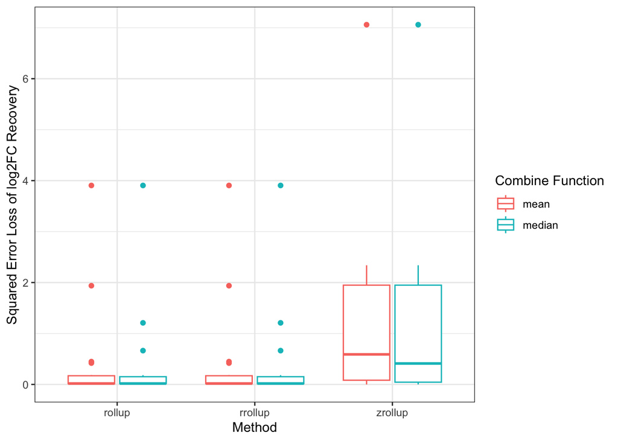

```r
ggdat = out_dat %>% mutate(SEL = (Fold_change_1_vs_2 - true_fold_change)^2)
ggplot(ggdat, aes(x = Method, y = SEL, color = Combine_Function)) +
  geom_boxplot() +
  ylab("Squared Error Loss of log2FC Recovery") +
  labs(color = 'Combine Function') +
  theme_bw()
```

## Adding Site Effect

Simulation setup:  
- 2 groups  
- 10 subjects per group  
- 1000 replicates of the sequence are simulated per subject  
- No subject effect  
- Gaussian site effect with sd = 0.1

Set simulation values:

```r
sequence_abundances = c(1000, 1000)

ptm_site_mapping = get_ptm_site_mapping(sequence, amino_acid)
site_sd = 0.1
site_coefs = rnorm(length(unique(ptm_site_mapping$site)), sd = site_sd)

n_per_group = 10
# subject_effect_sd = 0.1
# subject_coefs = rnorm(n_per_group * 2, sd = subject_effect_sd)
subject_coefs = rep(0, n_per_group * 2)
```

Simulate data:

```r
set.seed(seed)
out = generate_ptm_samples_for_sequence(ptm_site_mapping,
                                        sequence_abundances,
                                        subject_coefs,
                                        site_coefs,
                                        group_ids = rep(c(1, 2), each = n_per_group))

ground_truth = data.frame(site = rownames(out$ground_truth),
                          G1 = out$ground_truth[,1],
                          G2 = out$ground_truth[,2]) %>%
  mutate(true_fold_change = log2(G1 / G2)) %>%
  select(site, true_fold_change)

f_data_full = data.frame(sample = out$e_data %>% select(-peptide) %>% names,
                         group = rep(c(1, 2), each = n_per_group))
```

```r
pepdat = as.pepData(e_data = out$e_data,
                    f_data = f_data_full,
                    e_meta = out$e_meta %>% select(-group, -true_peptide_count) %>% distinct(),
                    edata_cname = "peptide",
                    fdata_cname = "sample",
                    emeta_cname = "site")
head(pepdat$e_data, 10) %>% knitr::kable()
```

| peptide | Subject_1_G1 | Subject_2_G1 | Subject_3_G1 | Subject_4_G1 | Subject_5_G1 | Subject_6_G1 | Subject_7_G1 | Subject_8_G1 | Subject_9_G1 | Subject_10_G1 | Subject_1_G2 | Subject_2_G2 | Subject_3_G2 | Subject_4_G2 | Subject_5_G2 | Subject_6_G2 | Subject_7_G2 | Subject_8_G2 | Subject_9_G2 | Subject_10_G2 |
| --- | --- | --- | --- | --- | --- | --- | --- | --- | --- | --- | --- | --- | --- | --- | --- | --- | --- | --- | --- | --- |
| AGNYTHVS#LPAK | 191.4567 | 191.4567 | 191.4567 | 191.4567 | 191.4567 | 191.4567 | 191.4567 | 191.4567 | 191.4567 | 191.4567 | 693.13472 | 693.13472 | 693.13472 | 693.13472 | 693.13472 | 693.13472 | 693.13472 | 693.13472 | 693.13472 | 693.13472 |
| ENLFWWVGFDAFYLYHDES#NAK | 311.8054 | 311.8054 | 311.8054 | 311.8054 | 311.8054 | 311.8054 | 311.8054 | 311.8054 | 311.8054 | 311.8054 | 175.19501 | 175.19501 | 175.19501 | 175.19501 | 175.19501 | 175.19501 | 175.19501 | 175.19501 | 175.19501 | 175.19501 |
| GQHGS#AVK | 302.4501 | 302.4501 | 302.4501 | 302.4501 | 302.4501 | 302.4501 | 302.4501 | 302.4501 | 302.4501 | 302.4501 | 459.09365 | 459.09365 | 459.09365 | 459.09365 | 459.09365 | 459.09365 | 459.09365 | 459.09365 | 459.09365 | 459.09365 |
| HS#HEMIS#MIQDFWTR | 535.6403 | 535.6403 | 535.6403 | 535.6403 | 535.6403 | 535.6403 | 535.6403 | 535.6403 | 535.6403 | 535.6403 | 35.52239 | 35.52239 | 35.52239 | 35.52239 | 35.52239 | 35.52239 | 35.52239 | 35.52239 | 35.52239 | 35.52239 |
| HS#HEMISMIQDFWTR | 240.3488 | 240.3488 | 240.3488 | 240.3488 | 240.3488 | 240.3488 | 240.3488 | 240.3488 | 240.3488 | 240.3488 | 33.81333 | 33.81333 | 33.81333 | 33.81333 | 33.81333 | 33.81333 | 33.81333 | 33.81333 | 33.81333 | 33.81333 |
| HSHEMIS#MIQDFWTR | 108.4272 | 108.4272 | 108.4272 | 108.4272 | 108.4272 | 108.4272 | 108.4272 | 108.4272 | 108.4272 | 108.4272 | 561.57104 | 561.57104 | 561.57104 | 561.57104 | 561.57104 | 561.57104 | 561.57104 | 561.57104 | 561.57104 | 561.57104 |
| IPTYS#YHANNFLTEWS#MVLPMLHNLHCWMR | 607.4354 | 607.4354 | 607.4354 | 607.4354 | 607.4354 | 607.4354 | 607.4354 | 607.4354 | 607.4354 | 607.4354 | 421.03153 | 421.03153 | 421.03153 | 421.03153 | 421.03153 | 421.03153 | 421.03153 | 421.03153 | 421.03153 | 421.03153 |
| IPTYS#YHANNFLTEWSMVLPMLHNLHCWMR | 124.2141 | 124.2141 | 124.2141 | 124.2141 | 124.2141 | 124.2141 | 124.2141 | 124.2141 | 124.2141 | 124.2141 | 76.59867 | 76.59867 | 76.59867 | 76.59867 | 76.59867 | 76.59867 | 76.59867 | 76.59867 | 76.59867 | 76.59867 |
| IPTYSYHANNFLTEWS#MVLPMLHNLHCWMR | 166.6411 | 166.6411 | 166.6411 | 166.6411 | 166.6411 | 166.6411 | 166.6411 | 166.6411 | 166.6411 | 166.6411 | 346.72105 | 346.72105 | 346.72105 | 346.72105 | 346.72105 | 346.72105 | 346.72105 | 346.72105 | 346.72105 | 346.72105 |
| MAMWAS#WR | 864.6275 | 864.6275 | 864.6275 | 864.6275 | 864.6275 | 864.6275 | 864.6275 | 864.6275 | 864.6275 | 864.6275 | 528.07358 | 528.07358 | 528.07358 | 528.07358 | 528.07358 | 528.07358 | 528.07358 | 528.07358 | 528.07358 | 528.07358 |

Pre-process data:

```r
pepdat = pmartR::edata_transform(pepdat, "log2")
pepdat = pmartR::normalize_global(pepdat, subset_fn = 'all', norm_fn = "median", apply_norm = T, backtransform = F)
pepdat = pmartR::applyFilt(pmartR::molecule_filter(pepdat), pepdat, min_num = 2)
pepdat = pmartR::group_designation(pepdat, main_effects = 'group')
```

Rollup:

```r
methods = c('rollup', 'rrollup', 'zrollup')
combine_fns = c("mean", "median")
combinations = expand.grid(method = methods, combine_fn = combine_fns)
out_dat = c()
for(i in seq_len(nrow(combinations))){
  method = combinations$method[i]
  combine_fn = combinations$combine_fn[i]
  single_pep = method == "zrollup"

  sitedat = pmartR::protein_quant(pepdat, method, combine_fn = combine_fn, single_pep = single_pep)
  tmp_res = imd_anova(sitedat, test_method = 'anova')
  res = data.frame(tmp_res %>%
                     select(site, starts_with("Fold_change")) %>%
                     left_join(., ground_truth, by = 'site'),
                   Method = method,
                   Combine_Function = combine_fn)

  out_dat = rbind(out_dat, res)
}
out_dat = as_tibble(out_dat)
```

Performance for each method compared to ground truth:

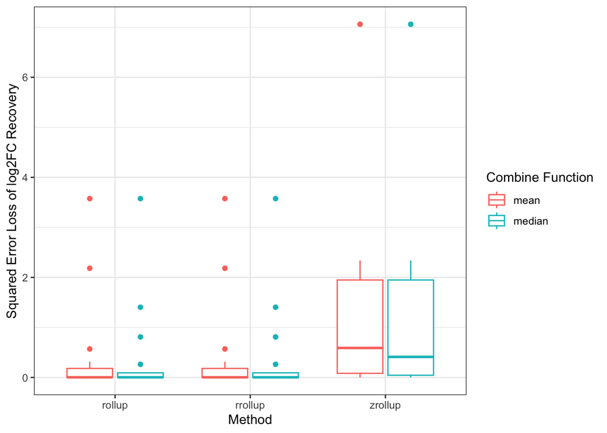

```r
ggdat = out_dat %>% mutate(SEL = (Fold_change_1_vs_2 - true_fold_change)^2)
ggplot(ggdat, aes(x = Method, y = SEL, color = Combine_Function)) +
  geom_boxplot() +
  ylab("Squared Error Loss of log2FC Recovery") +
  labs(color = 'Combine Function') +
  theme_bw()
```

## Adding Subject Effect

Set simulation values:

```r
sequence_abundances = c(1000, 1000)

ptm_site_mapping = get_ptm_site_mapping(sequence, amino_acid)
site_sd = 0.1
subject_coefs = rnorm(length(unique(ptm_site_mapping$site)), sd = site_sd)

n_per_group = 10
subject_effect_sd = 0.1
subject_coefs = rnorm(n_per_group * 2, sd = subject_effect_sd)
```

Simulate data:

```r
set.seed(seed)
out = generate_ptm_samples_for_sequence(ptm_site_mapping,
                                        sequence_abundances,
                                        subject_coefs,
                                        site_coefs,
                                        group_ids = rep(c(1, 2), each = n_per_group))

ground_truth = data.frame(site = rownames(out$ground_truth),
                          G1 = out$ground_truth[,1],
                          G2 = out$ground_truth[,2]) %>%
  mutate(true_fold_change = log2(G1 / G2)) %>%
  select(site, true_fold_change)

f_data_full = data.frame(sample = out$e_data %>% select(-peptide) %>% names,
                         group = rep(c(1, 2), each = n_per_group))
```

```r
pepdat = as.pepData(e_data = out$e_data,
                    f_data = f_data_full,
                    e_meta = out$e_meta %>% select(-group, -true_peptide_count) %>% distinct(),
                    edata_cname = "peptide",
                    fdata_cname = "sample",
                    emeta_cname = "site")
head(pepdat$e_data, 10) %>% knitr::kable()
```

| peptide | Subject_1_G1 | Subject_2_G1 | Subject_3_G1 | Subject_4_G1 | Subject_5_G1 | Subject_6_G1 | Subject_7_G1 | Subject_8_G1 | Subject_9_G1 | Subject_10_G1 | Subject_1_G2 | Subject_2_G2 | Subject_3_G2 | Subject_4_G2 | Subject_5_G2 | Subject_6_G2 | Subject_7_G2 | Subject_8_G2 | Subject_9_G2 | Subject_10_G2 |
| --- | --- | --- | --- | --- | --- | --- | --- | --- | --- | --- | --- | --- | --- | --- | --- | --- | --- | --- | --- | --- |
| AGNYTHVS#LPAK | 177.0777 | 220.2261 | 164.73786 | 189.8177 | 198.7840 | 185.1054 | 202.1780 | 201.9864 | 187.0110 | 193.9723 | 641.07804 | 797.28923 | 596.40391 | 687.20111 | 719.66170 | 670.14104 | 731.94920 | 731.25556 | 677.03996 | 702.24214 |
| ENLFWWVGFDAFYLYHDES#NAK | 288.3878 | 358.6591 | 268.29123 | 309.1362 | 323.7385 | 301.4617 | 329.2660 | 328.9540 | 304.5652 | 315.9024 | 162.03729 | 201.52085 | 150.74557 | 173.69525 | 181.89991 | 169.38319 | 185.00566 | 184.83034 | 171.12694 | 177.49698 |
| GQHGS#AVK | 279.7351 | 347.8980 | 260.24151 | 299.8610 | 314.0252 | 292.4168 | 319.3868 | 319.0842 | 295.4271 | 306.4241 | 424.61421 | 528.07976 | 395.02457 | 455.16355 | 476.66363 | 443.86392 | 484.80218 | 484.34276 | 448.43338 | 465.12589 |
| HS#HEMIS#MIQDFWTR | 495.4119 | 616.1287 | 460.88868 | 531.0549 | 556.1398 | 517.8712 | 565.6353 | 565.0993 | 523.2026 | 542.6783 | 32.85454 | 40.86019 | 30.56504 | 35.21830 | 36.88187 | 34.34399 | 37.51159 | 37.47604 | 34.69755 | 35.98914 |
| HS#HEMISMIQDFWTR | 222.2978 | 276.4650 | 206.80679 | 238.2913 | 249.5472 | 232.3756 | 253.8080 | 253.5675 | 234.7679 | 243.5069 | 31.27384 | 38.89432 | 29.09449 | 33.52387 | 35.10740 | 32.69163 | 35.70683 | 35.67299 | 33.02818 | 34.25762 |
| HSHEMIS#MIQDFWTR | 100.2840 | 124.7201 | 93.29558 | 107.4990 | 112.5768 | 104.8303 | 114.4990 | 114.3904 | 105.9095 | 109.8519 | 519.39522 | 645.95602 | 483.20067 | 556.76369 | 583.06294 | 542.94178 | 593.01816 | 592.45618 | 548.53123 | 568.94978 |
| IPTYS#YHANNFLTEWS#MVLPMLHNLHCWMR | 561.8150 | 698.7122 | 522.66437 | 602.2354 | 630.6825 | 587.2846 | 641.4508 | 640.8429 | 593.3306 | 615.4167 | 389.41069 | 484.29821 | 362.27424 | 417.42728 | 437.14484 | 407.06446 | 444.60865 | 444.18731 | 411.25508 | 426.56366 |
| IPTYS#YHANNFLTEWSMVLPMLHNLHCWMR | 114.8852 | 142.8792 | 106.87930 | 123.1507 | 128.9679 | 120.0935 | 131.1699 | 131.0456 | 121.3298 | 125.8462 | 70.84586 | 88.10884 | 65.90890 | 75.94295 | 79.53018 | 74.05763 | 80.88808 | 80.81143 | 74.82003 | 77.60514 |
| IPTYSYHANNFLTEWS#MVLPMLHNLHCWMR | 154.1258 | 191.6816 | 143.38542 | 165.2146 | 173.0186 | 161.1131 | 175.9728 | 175.8060 | 162.7717 | 168.8307 | 320.68116 | 398.82139 | 298.33419 | 343.75292 | 359.99041 | 335.21911 | 366.13689 | 365.78992 | 338.67010 | 351.27677 |
| MAMWAS#WR | 799.6912 | 994.5515 | 743.96392 | 857.2258 | 897.7177 | 835.9448 | 913.0453 | 912.1801 | 844.5507 | 875.9883 | 488.41352 | 607.42502 | 454.37797 | 523.55298 | 548.28349 | 510.55555 | 557.64489 | 557.11643 | 515.81158 | 535.01218 |

Pre-process data:

```r
pepdat = pmartR::edata_transform(pepdat, "log2")
pepdat = pmartR::normalize_global(pepdat, subset_fn = 'all', norm_fn = "median", apply_norm = T, backtransform = F)
pepdat = pmartR::applyFilt(pmartR::molecule_filter(pepdat), pepdat, min_num = 2)
pepdat = pmartR::group_designation(pepdat, main_effects = 'group')
```

Rollup:

```r
methods = c('rollup', 'rrollup', 'zrollup')
combine_fns = c("mean", "median")
combinations = expand.grid(method = methods, combine_fn = combine_fns)
out_dat = c()
for(i in seq_len(nrow(combinations))){
  method = combinations$method[i]
  combine_fn = combinations$combine_fn[i]
  single_pep = method == "zrollup"

  sitedat = pmartR::protein_quant(pepdat, method, combine_fn = combine_fn, single_pep = single_pep)
  tmp_res = imd_anova(sitedat, test_method = 'anova')
  res = data.frame(tmp_res %>%
                     select(site, starts_with("Fold_change")) %>%
                     left_join(., ground_truth, by = 'site'),
                   Method = method,
                   Combine_Function = combine_fn)

  out_dat = rbind(out_dat, res)
}
out_dat = as_tibble(out_dat)
```

Performance for each method compared to ground truth:

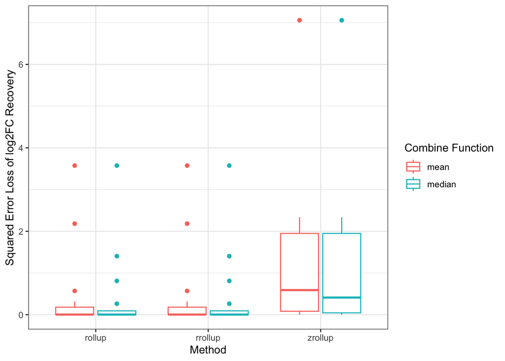

```r
ggdat = out_dat %>% mutate(SEL = (Fold_change_1_vs_2 - true_fold_change)^2)
ggplot(ggdat, aes(x = Method, y = SEL, color = Combine_Function)) +
  geom_boxplot() +
  ylab("Squared Error Loss of log2FC Recovery") +
  labs(color = 'Combine Function') +
  theme_bw()
```